# Ads Compaign AB Test

# A compact A/B testing notebook — EDA + Core Tests

This notebook contains a concise, practical workflow I used to evaluate a marketing A/B test. It focuses on the minimal, statistically sound steps needed to decide whether a campaign moved the primary KPI (conversion rate). I include brief notes and in-place interpretations to make the analysis easy to follow.

**Assumptions** - Unit of analysis is the user. If your raw data has multiple events per user, aggregate first. - Expected columns: `user_id`, `test_group` (values `A` and `B`).

## 1) Load data

```r
DATA_PATH <- "./marketing_AB.csv"
df_orgnl <- readr::read_csv(DATA_PATH, show_col_types = FALSE)

# display head
print(df_orgnl)
```

```
## # A tibble: 588,101 × 7
##     ...1 `user id` `test group` converted `total ads` `most ads day`
##    <dbl>     <dbl> <chr>        <lgl>           <dbl> <chr>
##  1     0   1069124 ad           FALSE             130 Monday
##  2     1   1119715 ad           FALSE              93 Tuesday
##  3     2   1144181 ad           FALSE              21 Tuesday
##  4     3   1435133 ad           FALSE             355 Tuesday
##  5     4   1015700 ad           FALSE             276 Friday
##  6     5   1137664 ad           FALSE             734 Saturday
##  7     6   1116205 ad           FALSE             264 Wednesday
##  8     7   1496843 ad           FALSE              17 Sunday
##  9     8   1448851 ad           FALSE              21 Tuesday
## 10     9   1446284 ad           FALSE             142 Monday
## # ℹ 588,091 more rows
## # ℹ 1 more variable: `most ads hour` <dbl>
```

## 2) Preprocess & sanity checks

Ensure a single row per user.

```r
df <- df_orgnl
summary(df)
```

```
##       ...1           user id         test group        converted
##  Min.   :     0   Min.   : 900000   Length:588101      Mode :logical
##  1st Qu.:147025   1st Qu.:1143190   Class :character   FALSE:573258
##  Median :294050   Median :1313725   Mode  :character   TRUE :14843
##  Mean   :294050   Mean   :1310692
##  3rd Qu.:441075   3rd Qu.:1484088
##  Max.   :588100   Max.   :1654483
##    total ads       most ads day       most ads hour
##  Min.   :   1.00   Length:588101      Min.   : 0.00
##  1st Qu.:   4.00   Class :character   1st Qu.:11.00
##  Median :  13.00   Mode  :character   Median :14.00
##  Mean   :  24.82                      Mean   :14.47
##  3rd Qu.:  27.00                      3rd Qu.:18.00
##  Max.   :2065.00                      Max.   :23.00
```

```r
colSums(is.na(df))
```

```
##          ...1       user id    test group     converted     total ads
##             0             0             0             0             0
##  most ads day most ads hour
##             0             0
```

```r
# Drop index-like column if present
if ("Unnamed: 0" %in% names(df)) df <- dplyr::select(df, -`Unnamed: 0`)

# Rename columns for easier access
rename_map <- c(
  `user id` = "user_id",
  `test group` = "test_group",
  `total ads` = "total_ads",
  `most ads day` = "most_ads_day",
  `most ads hour` = "most_ads_hour"
)
for (old in names(rename_map)) {
  new <- rename_map[[old]]
  if (old %in% names(df)) names(df)[names(df) == old] <- new
}
```

```
##
## Outlier Summary for total_ads:
## ---
## Total outliers: 52057
## Total records: 588101
## Percentage of outliers: 8.85%
```

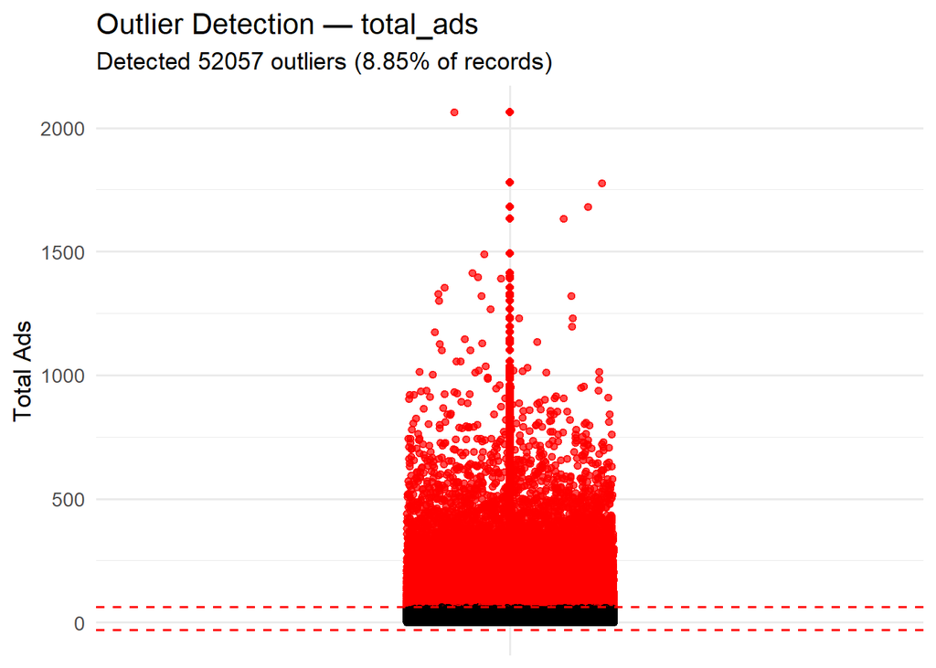

```r
filter_outliers <- function(x, whisker = 1.5) {
  q1 <- stats::quantile(x, 0.25, na.rm = TRUE)
  q3 <- stats::quantile(x, 0.75, na.rm = TRUE)
  iqr <- q3 - q1
  lower <- q1 - whisker * iqr
  upper <- q3 + whisker * iqr
  which(x < lower | x > upper)
}

if ("total_ads" %in% names(df) && any(!is.na(df$total_ads))) {
  idx <- filter_outliers(df$total_ads)
  total_outliers <- length(idx)
  total_records <- nrow(df)
  pct_outliers <- total_outliers * 100 / total_records

  cat(sprintf(
    "\nOutlier Summary for total_ads:\n---\nTotal outliers: %d\nTotal records: %d\nPercentage of outliers: %.2f%%\n\n",
    total_outliers, total_records, pct_outliers
  ))

  # Compute whiskers for reference lines
  q1 <- quantile(df$total_ads, 0.25, na.rm = TRUE)
  q3 <- quantile(df$total_ads, 0.75, na.rm = TRUE)
  iqr <- q3 - q1
  lower <- q1 - 1.5 * iqr
  upper <- q3 + 1.5 * iqr

  # create a plotting dataframe with an explicit outlier flag and a constant x value
  df_plot <- df %>%
    mutate(
      is_outlier = ifelse(!is.na(total_ads) & (total_ads < lower | total_ads > upper), TRUE, FALSE),
      grp = factor("all"),
      point_color = ifelse(is_outlier, "red", "black")    # concrete color values to avoid scale issues
    )

  # Create visualization and force it to render
  p <- ggplot(df_plot, aes(x = grp, y = total_ads)) +
    geom_boxplot(fill = "#9ecae1", color = "#2171b5",
                 outlier.colour = "red", outlier.shape = 16, width = 0.25) +
    # use identity scale by mapping to a concrete color column
    geom_jitter(aes(color = point_color),
                width = 0.15, alpha = 0.7, show.legend = FALSE, size = 1.5) +
    scale_color_identity() +
    geom_hline(yintercept = lower, linetype = "dashed", color = "red") +
    geom_hline(yintercept = upper, linetype = "dashed", color = "red") +
    labs(
      title = "Outlier Detection — total_ads",
      subtitle = sprintf("Detected %d outliers (%.2f%% of records)", total_outliers, pct_outliers),
      y = "Total Ads",
      x = NULL
    ) +
    theme_minimal(base_size = 13) +
    theme(axis.text.x = element_blank(), axis.ticks.x = element_blank())

  print(p)
} else {
  cat("No 'total_ads' column found or all values are NA - skipping outlier plot.\n")
}
```